# R para ciencia de datos - Ejercicios 3

Noelí D’Alessio

4/29/2020

```r
library(tidyverse)
library(dplyr)
library(datos)
```

#Atrasos por destino

```r
atrasos <- vuelos %>%
    group_by(destino) %>%
    summarise(
      conteo = n(),
      distancia = mean(distancia, na.rm = TRUE),
      atraso = mean(atraso_llegada, na.rm = TRUE)
    )%>%
    filter(conteo > 20, destino !='HNL')
```

#5.6.7 Ejercicios

- data %>% count(variable) - Cuenta cuántos vuelos se hicieron por destino

```r
not_cancelled <- vuelos %>%
    filter(!is.na(atraso_salida), !is.na(atraso_llegada))

not_cancelled %>% count(destino)
```

```
## # A tibble: 104 x 2
##    destino     n
##    <chr>   <int>
##  1 ABQ       254
##  2 ACK       264
##  3 ALB       418
##  4 ANC         8
##  5 ATL     16837
##  6 AUS      2411
##  7 AVL       261
##  8 BDL       412
##  9 BGR       358
## 10 BHM       269
## # ... with 94 more rows
```

- Tambien podriamos usar group_by(varible) y summarise(n = length(variable))

```r
not_cancelled %>%
  group_by(destino) %>%
  summarise(n = length(destino))
```

```
## # A tibble: 104 x 2
##    destino     n
##    <chr>   <int>
##  1 ABQ       254
##  2 ACK       264
##  3 ALB       418
##  4 ANC         8
##  5 ATL     16837
##  6 AUS      2411
##  7 AVL       261
##  8 BDL       412
##  9 BGR       358
## 10 BHM       269
## # ... with 94 more rows
```

- group by + summarise(n = n()) I

```r
not_cancelled %>%
  group_by(destino) %>%
  summarise(n = n())
```

```
## # A tibble: 104 x 2
##    destino     n
##    <chr>   <int>
##  1 ABQ       254
##  2 ACK       264
##  3 ALB       418
##  4 ANC         8
##  5 ATL     16837
##  6 AUS      2411
##  7 AVL       261
##  8 BDL       412
##  9 BGR       358
## 10 BHM       269
## # ... with 94 more rows
```

- group_by + tally()

```r
not_cancelled %>%
  group_by(codigo_cola) %>%
  tally()
```

```
## # A tibble: 4,037 x 2
##    codigo_cola     n
##    <chr>       <int>
##  1 D942DN          4
##  2 N0EGMQ        352
##  3 N10156        145
##  4 N102UW         48
##  5 N103US         46
##  6 N104UW         46
##  7 N10575        269
##  8 N105UW         45
##  9 N107US         41
## 10 N108UW         60
## # ... with 4,027 more rows
```

- count(wt=varible)

```r
not_cancelled %>%
  count(codigo_cola, wt = distancia)
```

```
## # A tibble: 4,037 x 2
##    codigo_cola      n
##    <chr>        <dbl>
##  1 D942DN        3418
##  2 N0EGMQ      239143
##  3 N10156      109664
##  4 N102UW       25722
##  5 N103US       24619
##  6 N104UW       24616
##  7 N10575      139903
##  8 N105UW       23618
##  9 N107US       21677
## 10 N108UW       32070
## # ... with 4,027 more rows
```

-Parecido, pero en vez del argumento wt usamos group_by y summarise

```r
not_cancelled %>%
  group_by(codigo_cola) %>%
  summarise(n = sum(distancia))
```

```
## # A tibble: 4,037 x 2
##    codigo_cola      n
##    <chr>        <dbl>
##  1 D942DN        3418
##  2 N0EGMQ      239143
##  3 N10156      109664
##  4 N102UW       25722
##  5 N103US       24619
##  6 N104UW       24616
##  7 N10575      139903
##  8 N105UW       23618
##  9 N107US       21677
## 10 N108UW       32070
## # ... with 4,027 more rows
```

- Group_by + tally(variable) - el argumento de tally se suma

```r
not_cancelled %>%
  group_by(codigo_cola) %>%
  tally(distancia)
```

```
## # A tibble: 4,037 x 2
##    codigo_cola      n
##    <chr>        <dbl>
##  1 D942DN        3418
##  2 N0EGMQ      239143
##  3 N10156      109664
##  4 N102UW       25722
##  5 N103US       24619
##  6 N104UW       24616
##  7 N10575      139903
##  8 N105UW       23618
##  9 N107US       21677
## 10 N108UW       32070
## # ... with 4,027 more rows
```

4.Mira la cantidad de vuelos cancelados por día. ¿Hay un patrón? ¿La proporción de vuelos cancelados está relacionada con el retraso promedio?

Primero, me gustaría ver si la cantidad de vuelos cancelados aumenta cuando hay más cantidad de vuelos por día, ya que más vuelos debería ser más demora.

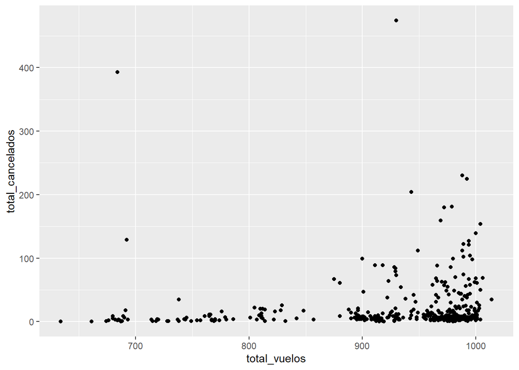

```r
cancelados_por_dia <-
  vuelos %>%
   mutate(cancelados = (is.na(horario_salida) | is.na(horario_llegada)))%>%
  group_by(anio, mes, dia) %>%
    summarise(
      total_cancelados = sum(cancelados),
      total_vuelos = n(),
    )

ggplot(cancelados_por_dia) +
  geom_point(aes(x=total_vuelos, y=total_cancelados))
```

Al parecer, a medida que aumenta la cantidad de vuelos, aumenta tambien el numero de vuelos cancelados.

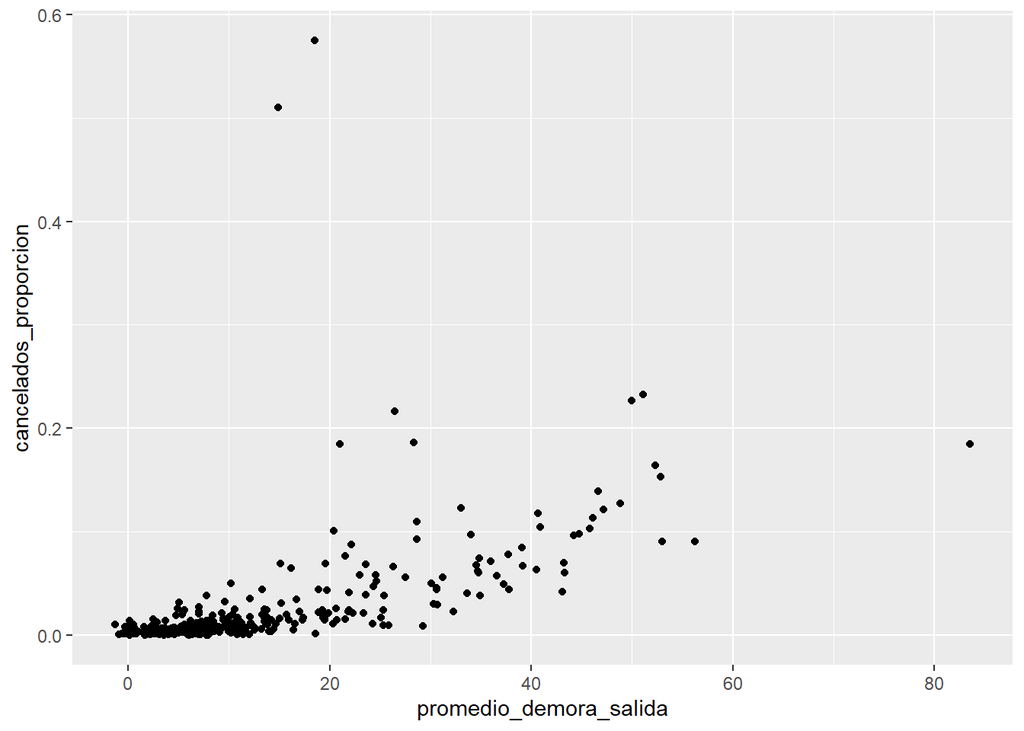

```r
cancelados_dia_demora <-
    vuelos %>%
    mutate(cancelados= (is.na(horario_salida) | is.na(horario_llegada))) %>%
    group_by(anio, mes, dia) %>%
    summarise(
      promedio_demora_salida = mean(atraso_salida, na.rm = TRUE),
      promedio_demora_llegada = mean(atraso_llegada, na.rm = TRUE),
      cancelados_proporcion = mean(cancelados)
    ) %>%
  ungroup()

ggplot(cancelados_dia_demora) +
  geom_point(aes(y = cancelados_proporcion, x = promedio_demora_salida))
```

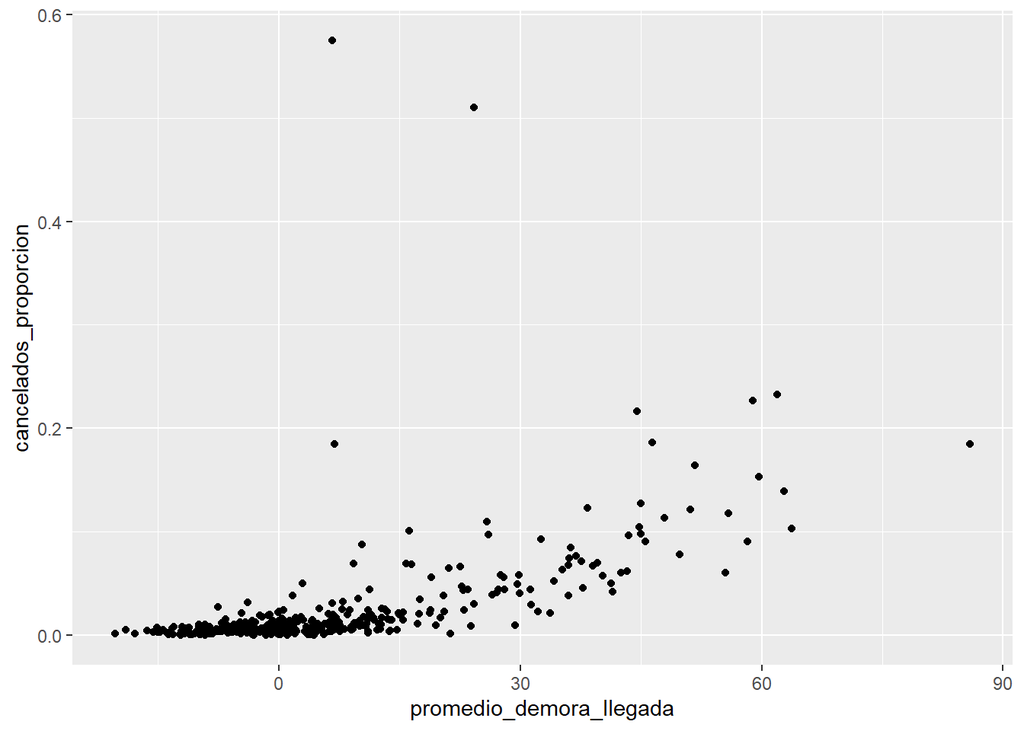

```r
ggplot(cancelados_dia_demora) +
  geom_point(aes(y = cancelados_proporcion, x = promedio_demora_llegada))
```

5. ¿Qué compañía tiene los peores retrasos? Desafío: ¿puedes desenredar el efecto de malos aeropuertos vs. el efecto de malas aerolíneas? ¿Por qué o por qué no? (Sugerencia: piensa en vuelos %>% group_by(aerolinea, destino) %>% summarise(n()))